# Summary

Vanessa Izaguirre

24/5/2022

# **Introducción**

La adaptación local es una estrategia de supervivencia de las poblaciones frente a los rápidos cambios ambientales. Ésta puede entenderse como la adquisición de la o las características que permite a los genotipos locales tener un mayor fitness en su hábitat de origen en comparación con los genotipos de otros hábitats (Savolainen et al, 2007). Para que la adaptación local suceda es necesario la selección actúe sobre los fenotipos de las poblaciones que se enfrenten a distintas presiones selectivas bajo la heterogeneidad de los gradientes ambientales. Entender cómo ocurre este proceso es útil para comprender la divergencia adaptativa inicial y el potencial evolutivo de las especies.

Los métodos dentro de la genómica del paisaje nos brindan una oportunidad para comprender los procesos de adaptación local, dividiéndose en dos clases: pruebas de valores atípicos basados en la diferenciación genética y asociación genotipo-ambiente. Estas pruebas operan bajo el supuesto de que la selección natural que varía espacialmente a lo largo de gradientes ambientales conducirá a una diferenciación genética alta entre las poblaciones en loci adaptados localmente o a asociaciones genotipo-ambiente significativas (Gugger et al, 20020).

Este trabajo busca identificar si existen loci candidatos bajo selección natural y si hay asociaciaciones ambientales que sugieran procesos de adaptación local con datos de 11 poblaciones de *Juniperus monticula*, una especie de planta de pastizales alpinos distribuida a través de los sistemas montañosos mexicanos, descargados del artículo **“Long‐term in situ persistence of biodiversity in tropical sky islands revealed by landscape genomics”** https://onlinelibrary.wiley.com/doi/abs/10.1111/mec.14461.

# **Métodos**

Se descargaron las 19 variables bioclimáticas disponibles en la base de datos de Worldclim (http://www.worldclim.org). Los valores para cada sitio se extrajeron por medio del paquete raster en R. Posteriormente se evaluó si había multicolinealidad utilizando los factores de inflación de varianza (VIF) reteniendo sólo las variables con un VIF menor a 10 (Montgomery y Peck 1992). Se mantuvieron solo las siguientes: isotermalidad (bio3), temperatura media del trimestre más seco (bio9), precipitación del trimestre más seco (bio17) y precipitación del trimestre más cálido (bio18).

Para identificar las regiones genómicas bajo selección divergente se utilizó el software Bayescan v2.1. Para esto se evaluaron 2904 SNPs utilizando los siguientes parámetros: las probabilidades anteriores para el modelo neutral se establecieron en 100, con 5000 iteraciones, un tamaño de intervalo de 10, 20 ejecuciones piloto, 5000 iteraciones para las ejecuciones piloto y un burn-in de 50,000 iteraciones. Los valores *Q* fueron calculados y aquellos SNPs con *q< 0.001* fueron considerados como valores atípicos.

Para identificar SNP candidatos que pueden estar bajo selección natural por asociaciones con variables ambientales se utilizaron modelos mixtos de factores latentes (LFMM; Frichot et al, 2013) implementados en el paquete LEA en R (Frichot & François, 2015). Para seleccionar el número “óptimo” de factores latentes se usó el número de grupos inferidos de sNMF y se verificaron los histogramas de los valores *p* para garantizar que la tasa de falsos positivos estuviera bien controlada. Se hiceron cinco ejecuciones independientes utilizando 10000 iteraciones y un período de burn-in de 5000. Los valores de *p* ajustados (*q*) se calcularon utilizando el procedimiento del factor de inflación genómica (*λ*) (Devlin y Roeder 1999).

# **Resultados**

El análisis con Bayescan encontró tres SNPs (0.10% de 2904) con valores elevados de *FST*, sugiriendo selección divergente. No se identificaron valores atípicos bajos de *Fst* los cuales podrían ser indicativos de selección balanceadora o purificadora.

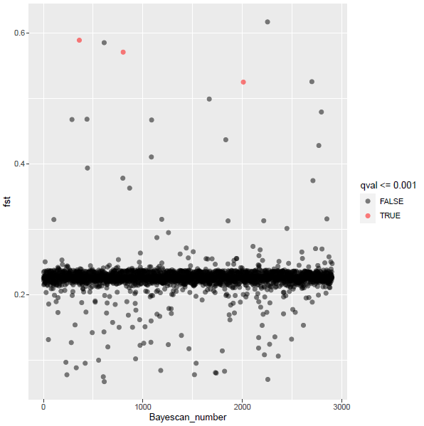

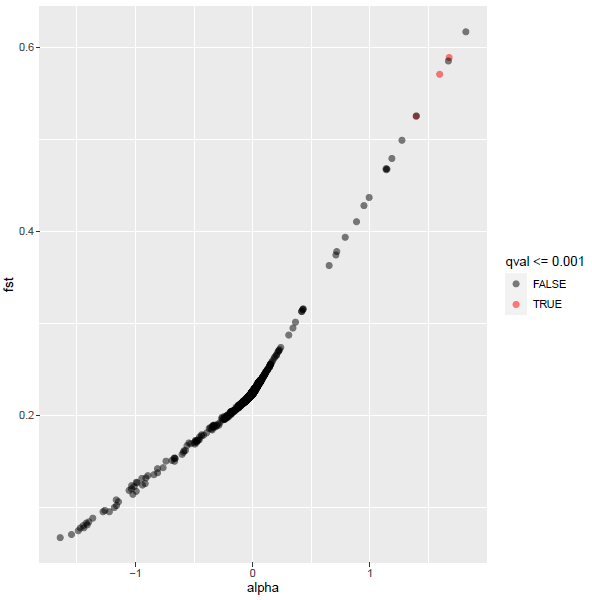

A través del LFMM, se encontraron 226 SNPs (7.7% de 2904) que estuvieron significativamente asociados con variables climáticas; estos SNPs, a excepción de uno, fueron diferentes a aquellos identificados previamente con Bayescan. De los 226 SNPs, 141 estuvieron asociados con la precipitación, siendo la precipitación del trimestre más cálido (bio18) la que tuvo el mayor número de SNPs asociados(91 SNPs). 85 SNPs estuvieron asociados con la temperatura siendo la isotermalidad (bio3) la variable con más asociaciones (52 SNPs).

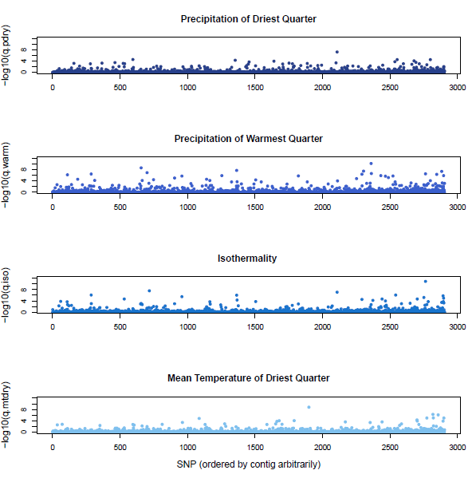

En conjunto, Bayescan y LFMM encontraron 228 SNP candidatos

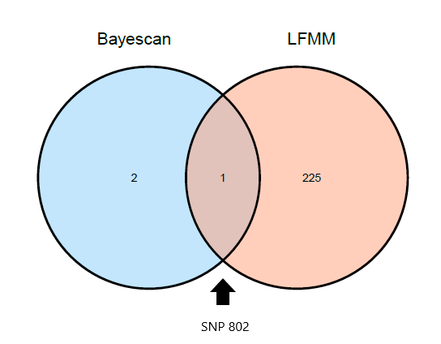

Sería interesante contar con un genoma de referencia para poder encontrar las funciones asociadas a estos SNPs candidatos.

## **Referencias**

Frichot E. & Francois O, 2014. “LEA: an R package for Landscape and Ecological Association studies.” *under review*. <URL: http://membres-timc.imag.fr/Olivier.Francois/lea.html>

Frichot, E., Schoville, S. D., Bouchard, G., & François, O. (2013). Testing for associations between loci and environmental gradients using latent factor mixed models. Molecular Biology and Evolution, 30(7), 1687–1699. https://doi.org/10.1093/molbev/mst063

Gugger, P. F., Fitz‐Gibbon, S. T., Albarrán‐Lara, A., Wright, J. W., & Sork, V. L. (2021). Landscape genomics of Quercus lobata reveals genes involved in local climate adaptation at multiple spatial scales. Molecular Ecology, 30(2), 406-423.

Mastretta‐Yanes, A., Xue, A. T., Moreno‐Letelier, A., Jorgensen, T. H., Alvarez, N., Pinero, D., & Emerson, B. C. (2018). Long‐term in situ persistence of biodiversity in tropical sky islands revealed by landscape genomics. Molecular Ecology, 27(2), 432-448.

Montgomery & Peck, E. 1992. Introduction to Linear Regresión Análisis. 2da.

Savolainen, O., Pyhajarvi, T., & Knurr, T. (2007). Gene flow and local adaptation in trees. Annual Review of Ecology Evolution and Systematics, 38, 595–619. https://doi.org/10.1146/Annurev.Ecolsys.38.091206.095646